# The mechanics of foreign investments

This notebook is aimed at explaining how a (probably currency-hedged) foreign investment would work.

Let's start by using a simple example of an American investor willing to invest in the Swiss market.

## Starting situation

Let's assume that our investor has at $t_0$ an amount of dollars $Z_0$. If $S_0 = \frac{1}{USDCHF}$ (i.e. how many USD we pay for each CHF), and $I_0$ is the amount of CHF we would get for $Z_0$ USD, we have that $Z_0 = S_0 I_0$ is the value of our wealth at time 0 denominated in USD.

We can now invest our $I_0$ Swiss francs in the Swiss market with an initial USD value of our position equal to $S_0 I_0$.

On the other hand, if we were willing to hedge partially our currency exposure we could enter into a forward contract to **sell** an amount of $H I_0$ CHF at a price of $F_m$ USD, at a future time $t_m$, where $H$ is the fraction of exposure we want to cover, i.e. the hedge ratio and $t_m$ is a future date that will not generally match the date in which we will unwind our foreign positions.

Hence, the USD value of our position at $t_0$ is $S_0 I_0$ USD, since we don't need to pay anything at $t_0$ for entering the forward contract.

## Final situation

Between $t_0$ and $t_1$ the return of the Swiss market has been $r_e$ and the return of the spot rate $\left( \frac{S_1}{S_0} - 1\right)$ is $r_s$. Therefore, the USD denominated wealth the we get from our investment is:$$ I_0 S_0 (1 + r_s) (1 + r_e)$$

Whereas the USD value of our short forward contract at $t_1$, provided that there is daily settlement of the position, is: $$ I_0 H (F_0 - F_1) $$

## Total return of our foreign investment

Now we can that the return of our foreign investment as:

$$ R = \frac{I_0 S_0 (1 + r_s) (1 + r_e) + I_0 H (F_0 - F_1)}{S_0 I_0} - 1$$

In order to simplify this expression we need to recall that the theoretical forward prices at $t_i$ are:

$$ F_{m}(t_i) = S(t_i) \frac{(1 + r_{C2}(t_i))^{\frac{t_m - t_i}{360}}}{(1 + r_{C1}(t_i))^{\frac{t_m - t_i}{360}}} $$

In order to simplify, let's use the concept of swap point (but in percentage):

$$ SP_{m}(t_i) = \frac{(1 + r_{C2}(t_i))^{\frac{t_m - t_i}{360}}}{(1 + r_{C1}(t))^{\frac{t_m - t_i}{360}}} - 1 $$$$ F_{m}(t_i) = S(t_i) (1 + SP_m(t_i))$$

For simplicity, we take:

$SP_m(t_0)=SP_{m0} \\ SP_m(t_1)=SP_{m1} \\ F_m(t_0) = F_0 \\ F_m(t_1) = F_1\\ S(t_0)=S_0 \\ S(t_1)=S_1 $

So we can now simplify the total return expression: $$R = (1+r_s) (1+r_e) + H \frac{F_0}{S_0} - H \frac{F_1}{S_0} - 1$$

$$ R = r_s + r_e + r_s \ r_e + H(1 + SP_{m0}) - H(1+SP_{m1})(1+r_s)$$

Finally, we can reagruping terms we get a nice and interpretable expression:

$$ R = r_s(1 - H) + r_e + r_s \ r_e + H \ SP_{m0} - H \ SP_{m1} \ (1 + r_s)$$

## Analysis of the final return

So the components of our return are:

1. $r_s(1 - H)$: The portion of the return of the spot that we are still exposed to.
2. $r_e$: The return of our investment (computed from the local currency prices of the investments).
3. $r_s \ r_e$: A non-linear term. This term accounts for the fact that you only hedge the portion of wealth that you have at $t_0$ (i.e. $I_0$) but since you don't know the return $r_e$ at $t_0$ you cannot hedge this profit/loss, there's a nominal mismatch. Generally speaking we can neglect this term for a daily horizon. For a long enough horizon it won't be negigible and we could make the hedge for an amount $I_0 (1 + \mathbb{E}[r_e])$, with non-trivial implications for the statistical framework.
4. $H \ SP_{m0}$: The hedging cost, defined by the cumulation of the interest rate difference from $t_0$ to $t_m$.
5. $H \ SP_{m1} \ (1 + r_s)$: This term appears because $t_1 \ne t_m$ so there is a maturity mismatch between the investment horizon and the maturity of the forward contract. For simplicity, we could avoid having this term, for example, assuming that we are using daily forwards (or with maturities exactly matching our investment horizons). Please note that $SP_{m1} =0$ if $t_m=t_1$.

Generally speaking we can say that we can get rid of some of the term 5 with a simplifying assumption. With these being in place we get this expression: $$ R = r_s(1 - H) + r_e + r_s \ r_e + H \ SP$$

So we only keep: outstanding exposure to the currency return, return of the investment, unhedgable currency risk (nominal mismatch) and hedging cost.

There are two very important cases to analyse, $H=0$ and $H=1$:

1. $H=0$: In the unhedged case, the total return of our foreign investment is $R=r_s + r_e + r_s \ r_e $
2. $H=1$: In the fully hedged case, the total return of our foreign investment is $R=r_e + SP + r_s \ r_e $ ##### Consequently, regardless your hedging policy, pure foreign returns are unatailable for the America investor ($R\ne r_e$) always.

## Risk perspective

Once we have an expression for the total return of a foreign investment we can define the problem of having a portfolio of foreign investments and what are the elements that are going to be important when trying to find the currency hedges that minimize our overall risk.

Now we have two foreign investments in country 1 and country 2. We assume that we have a static asset allocation ($w_1$ and $w_2$) such that $w_1=1-w_2$. We define:

- $H_1$ and $H_2$: the currency hedge ratios for currency 1 and 2.
- $r_{s1}$ and $r_{s2}$: the spot return for currency 1 and 2.
- $r_{e1}$ and $r_{e2}$: the market return for currency 1 and 2.
- $SP_1$ and $SP_2$: the hedge cost for currency 1 and 2.

In this section, we are going to consider negligible the term $r_s \ r_e$, since it won't have an important impact and this way we get a linear expression for the foreign investment return.

Given that, the total return of our international portfolio is:

$$ R_t = w_1 R_1 + w_2 R_2$$$$ R_t = w_1 (1 - H_1)r_{s1} + w_1 r_{e1} + w_1 H_1 SP_1 \\ \, \, \, \, \, \, \, + w_2 (1 - H_2)r_{s2} + w_2 r_{e2} + w_2 H_2 SP_2$$

In this formulation we consider that the return $R_t$ is happening between two time periods and our aim is to find the currency hedges $H_1$ and $H_2$ such that we minimize the variance of $R_t$.

This being said, it's important to notice that the variance of $SP_1$ and $SP_2$ conditioned on the information available at the beginning of the period is **0**, because the cost of carry is known before-hand when entering a forward currency contract.

Therefore, the conditional variance of $R_t$ dependes only on the variance of the random variables $r_{s1}$, $r_{e1}$ and $r_{s2}$, $r_{e2}$.

We can express the variance of the foreign portfolio in terms of the random vector

$$\begin{bmatrix}r_{e1} & r_{s1} & r_{e2} & r_{s2} \end{bmatrix}$$

We can assume the probability distribution of the random vector as a multivariate normal with covariance matrix $\Sigma$ and mean vector $\mu$. Under this assumption, the hedging problem we are trying to solve would be mathematically expressed as:

$$\operatorname*{argmin}_{H_1, H_2} \, \, w_h^T \ \Sigma \ w_h$$

Where $w_h = \begin{bmatrix} w_1 & w_1 \ (1 - H_1) & w_2 & w_2 \ (1 - H_2) \end{bmatrix}$ and the variables to optimize are $H_1$ and are $H_2$.

##### From this very simple example, it seems obvious that the relevant covariance structure is the one associated with the random vector formed by the local-currency returns of the foreign market and the returns of the spot rates for the relevant exchange rates.

It is also nice to note that if the covariance structure between the spot rates and the indexes is dynamic rather than static ($\Sigma(t)$) the optimal currency hedge ratios become also dynamic ($H(t)$). This clearly makes the case for active currency overlay.

## Markowitz perspective

Even though it is possible to set up a mean variance optimization in the former framework, it is also possible to do it in different terms, which would involve different time series in the covariance analyis.

From the expression of the foreign investment return $$ R = r_s(1 - H) + r_e + r_s \ r_e + H \ SP$$

$$ R = r_s + r_e +r_s \ r_e + H (SP - r_s)$$

Where $r_{uh} = r_s + r_e + r_s \ r_e $ is the unhedged foreign investment return and $r_f = SP - r_s$ is the return of the hedge (short forward), so:

$$ R = r_{uh} + H \ r_f$$

and given that both $r_{uh}$ and $r_f$ are still approximately normal, having again a foreign portfolio $ R_t = w_1 R_1 + w_2 R_2$, we can set up a mean variance optimization:

$$\operatorname*{argmin}_{H_1, H_2} \, \, w_h^T \ \Sigma \ w_h - \lambda \ w_h^T \ \mu $$

Where $w_h = \begin{bmatrix} w_1 & H_1 & w_2 & H_2 \end{bmatrix}$ and $\Sigma$ and $\mu$ are he covariance and mean of the multivariate normal of the random vector

$$\begin{bmatrix}r_{uh1} & r_{f1} & r_{uh2} & r_{f2} \end{bmatrix}$$

Additionally the optimization problem is subject to $$ 0 <= H_1 <= w_1 \\ 0 <= H_2 <= w_2$$ in order leverage or invert the currency exposure of our investment.

##### In this case, the relevant covariance structure is the one associated with the random vector formed by the unhedged returns of the foreign market and the hedges.

We could additionally set the problem as the inverse one where we consider participations of currency risk as the variables instead of the hedge ratios, with the following definition of the return

$$R = r_h + P \ r_p$$

Where $r_h = r_e + SP + r_s \ r_e $ is the return of the hedged foreign investment, $P=1-H$ is the currency participation ratio and $r_p=r_s - SP$ is the return on the currency exposure.

##### In this case, the relevant covariance structure is the one associated with the random vector formed by the hedged returns of the foreign market and the return of the participation in the currency market.

# Some conclusions:

There are three possible sets of time series whose covariance structure could be useful for the problem of foreign investments:

1. Raw local indexes returns and currency spot rate returns.
2. Unhedged indexes returns and currency hedge returns.
3. Hedged indexes returns and currency exposure returns.

It's to us selecting which one of the three are we going to use in order to model de covariance matrix.

### In our opinion the most natural way to go for the modelling is option 1: using raw local returns for the indexes and the returns of the spot rates for the currencies as elements of the random vector whose dynamic covariance we are going to model.

# Indexes:

Even though we can use the local equity indexes for the analysis, we add here the computations of the hedged an unhedged versions of the indexes (which are the investable ones). These series could be useful to compare volatilities or compute correlations for different comparative reasons. Also for computing the results of a hedging strategy.

```python
import pandas as pd
import numpy as np
import matplotlib.pyplot as plt
from datetime import date
```

```python
data = pd.read_csv('dataset.csv', index_col=0, parse_dates=True)
```

```python
data.fillna(method='ffill', inplace=True)
data = data.loc[data.index>='19900101']
data = data.join(pd.DataFrame(data['S&P 500'].values/data['S&P 500'].values, index=data.index, columns=['USDUSD']))
```

```python
indx = ['EuroStoxx 50', 'Nikkei 225', 'SMI', 'FTSE 100', 'S&P 500']
local_currency = pd.Series(np.asarray(['EUR','JPY','CHF','GBP','USD']), index=indx)
```

# Unhedged & Hedged indexes

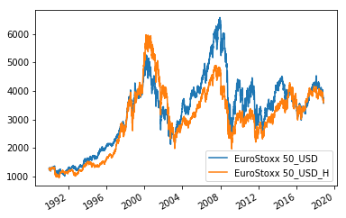

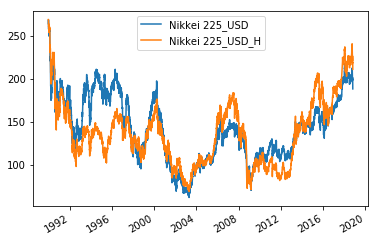

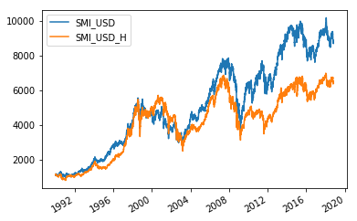

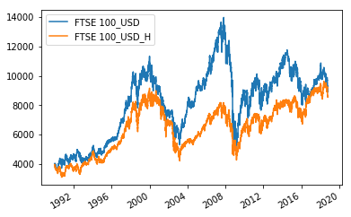

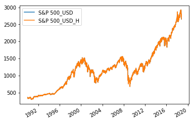

```python
check = pd.DataFrame(index=data.index, columns=[x+'_C' for x in indx])
local = 'USD'
unhedged_index = pd.DataFrame(index=data.index, columns=[x+'_'+local for x in indx])
hedged_index = pd.DataFrame(index=data.index, columns=[x+'_'+local+'_H' for x in indx])
for i in range(len(indx)):
    cross = local_currency[indx[i]] + local
    if cross in data.columns:
        direction = 1
    else:
        cross =  local + local_currency[indx[i]]
        direction = -1

    re = data[indx[i]].pct_change()
    rs = (data[cross]**direction).pct_change()
    sp = (1 + data[local+' 1M Libor'])**(1/360)/(1 + data[local_currency[indx[i]]+' 1M Libor'])**(1/360)-1

    unhedged = re + rs + rs*re
    hedged = re + rs*re + sp
    ini = (data[cross][0]**direction)*data[indx[i]][0]
    unhedged_index[indx[i]+'_'+local] = ini*(unhedged+1).cumprod()-1
    hedged_index[indx[i]+'_'+local+'_H'] = ini*(hedged+1).cumprod()-1

    (pd.DataFrame(unhedged_index[indx[i]+'_'+local]).join(hedged_index[indx[i]+'_'+local+'_H'])).plot()
```

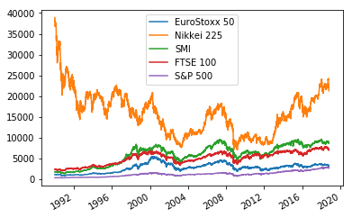

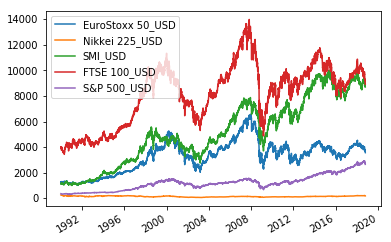

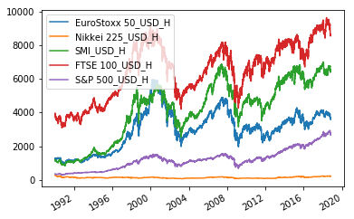

```python
data[indx].plot()
unhedged_index.plot()
hedged_index.plot()
```